# Cyclistic_case_study

KB

2023-07-11

## Business task for cyclistic case study

cyclistc is a bike sharing company based in chicago. Based on collected data stakeholders are interested in finding out how to convert casual riders into paying annual members. For easy conversion understanding behavours of each group on while using cyclistics is the one of the 3 focus of the team. which I was assinged to find out how casual riders differ from annual members in using thier services. which will be my business task for this project.

## Stakeholders

1, cyclistic: bike sharing company 2, Cyclistic exeecutive team: approver of recommended marketing program. 3, Lily Moreno: director of marketig and manager 4, Cyclistic Marketing analytics team: source, collector and analysiers of data that helps guide cyclistic’s marketing strategy.

## Data used for this analysis

Data used for this analysis was pre-collected for me by the cyclistic marketing analytics team. I have downloaded and stored the data approprately and created a dublicate of orgnal data before beging analysis.

## Installing and Loading packages

```r
install.packages("tidyverse", repos = "http://cran.us.r-project.org")
install.packages("lubridate", repos = "http://cran.us.r-project.org")
```

```r
install.packages("ggplot", repos = "http://cran.us.r-project.org")
```

tidyverse, lubridate and ggplot will be the packages I will use for this project.

```r
library(tidyverse)
```

```r
library(lubridate)
library(ggplot2)
library(readr)
```

using the import function I will be loading the data to working environment. importing cvs data could be done using read_csv function as well.

## Importing dataframes

```r
data01<-read.csv(file.choose())
data02<-read.csv(file.choose())
data03<-read.csv(file.choose())
data04<-read.csv(file.choose())
data05<-read.csv(file.choose())
data06<-read.csv(file.choose())
data07<-read.csv(file.choose())
data08<-read.csv(file.choose())
data09<-read.csv(file.choose())
data10<-read.csv(file.choose())
data11<-read.csv(file.choose())
data12<-read.csv(file.choose())
all_trips<-bind_rows(data01,data02,data03,data04,data05,data06,data07,data08,data09,data10,data11,data12)
```

it is crucial to check all data sets have similar column before merging. using bind_rows function I will merge each indvidual data set into one merged large data set to work with.

```r
colnames(all_trips)
```

```
##  [1] "ride_id"            "rideable_type"      "started_at"
##  [4] "ended_at"           "start_station_name" "start_station_id"
##  [7] "end_station_name"   "end_station_id"     "start_lat"
## [10] "start_lng"          "end_lat"            "end_lng"
## [13] "member_casual"
```

```r
view(all_trips)
```

using colnames we will check if all our colnms are present and joined properly. the function view will display our merged up data set for furtur review of proper merge or any errors.

## Data Cleaning

```r
all_trips_2 <- all_trips %>%
  select(ride_id,rideable_type,started_at,ended_at,start_station_name,end_station_name,
         start_station_id,end_station_id,member_casual)
```

since some of the colums are not needed for this analysis I will create a new data set named all_trips_2 which will include selected columns in the data set.

```r
all_trips_2$trip_duration <- difftime(all_trips_2$ended_at,all_trips_2$started_at)
```

It is also posiblile to do this exact thing by using all_trips_2$trip_duration <- difftime(all_trips_2$ended_at,all_trips_2$started_at). Both codes will create a new column named trip_duration which is based on the diffrential of ended_at column and started_at column.

```r
all_trips_2$trip_duration <- as.numeric(as.difftime(all_trips_2$trip_duration))
```

converting trip_duration into numeric value to enable calculations.

```r
is.numeric(all_trips_2$trip_duration)
```

```
## [1] TRUE
```

checking if trip_duration has been converted to numeric value.

```r
all_trips_2$date <- as.Date(all_trips_2$started_at)
all_trips_2$month <- format(as.Date(all_trips_2$date),"%m")
all_trips_2$day <- format(as.Date(all_trips_2$date),"%d")
all_trips_2$year <- format(as.Date(all_trips_2$date),"%Y")
all_trips_2$day_of_week <- format(as.Date(all_trips_2$date),"%A")
```

using above code chunk I am adding new columns month, day, year, and day_of_weak based on existing column named started_at. This will help in aggregating ride data based on each day, month or and year.

```r
table(all_trips$member_casual)
```

```
##
##  casual  member
## 2322032 3345685
```

checking how many rider types are present to furture clean our dataframe.

```r
all_trips_3 <- unique(all_trips_2)
all_trips_3 <- distinct(all_trips_2)
all_trips_3 <- all_trips_3[complete.cases(all_trips_2),]
```

since I am removing data I Will create a new version called all_trips_3. Code chunk will remove dublicates and any missing values. its important to consult with stakeholders about missing values before removing as it can be filled to make it complete. but on this case I Will remove it.

```r
table(all_trips_3$rideable_type)
```

```
##
##  classic_bike   docked_bike electric_bike
##       2601214        177474       2889029
```

checking how many types of rideable_types are stored in the data frame.

```r
all_trips_3 <- all_trips_3[!(all_trips_3$start_station_name=="HQ QR" | all_trips_3$trip_duration <0 | all_trips_3$rideable_type=="docked_bike"),]
```

removing any bike that is docked or its start_staton_name is HQ QR. any trip_duration stored as a negative number is also removed.

```r
data(all_trips_3)
```

loading dataframe for final review before analysis.

## Analysis

```r
min(all_trips_3$trip_duration)  # is 0 sec
```

```
## [1] 0
```

```r
max(all_trips_3$trip_duration)  # is 89965 sec
```

```
## [1] 90055
```

```r
median(all_trips_3$trip_duration) #is 616 sec
```

```
## [1] 602
```

```r
mean(all_trips_3$trip_duration)  #is  941.6771 sec
```

```
## [1] 966.5024
```

Doing calculations on trip_duration column to find out how bikes are used.

```r
aggregate(all_trips_3$trip_duration~all_trips_3$member_casual, FUN=mean)
```

```
##   all_trips_3$member_casual all_trips_3$trip_duration
## 1                    casual                 1284.1948
## 2                    member                  762.8665
```

```r
aggregate(all_trips_3$trip_duration~all_trips_3$member_casual, FUN=median)
```

```
##   all_trips_3$member_casual all_trips_3$trip_duration
## 1                    casual                       737
## 2                    member                       530
```

```r
aggregate(all_trips_3$trip_duration~all_trips_3$member_casual, FUN=min)
```

```
##   all_trips_3$member_casual all_trips_3$trip_duration
## 1                    casual                         0
## 2                    member                         0
```

```r
aggregate(all_trips_3$trip_duration~all_trips_3$member_casual, FUN=max)
```

```
##   all_trips_3$member_casual all_trips_3$trip_duration
## 1                    casual                     90055
## 2                    member                     89998
```

Doing calculations to find out how different members use the bikes

```r
aggregate(all_trips_3$trip_duration~all_trips_3$member_casual+all_trips_3$day_of_week, FUN=mean)
```

```
##    all_trips_3$member_casual all_trips_3$day_of_week all_trips_3$trip_duration
## 1                     casual                  Friday                 1228.6906
## 2                     member                  Friday                  751.8463
## 3                     casual                  Monday                 1284.9152
## 4                     member                  Monday                  736.2065
## 5                     casual                Saturday                 1425.4071
## 6                     member                Saturday                  848.3793
## 7                     casual                  Sunday                 1458.8591
## 8                     member                  Sunday                  842.1257
## 9                     casual                Thursday                 1159.9429
## 10                    member                Thursday                  737.5637
## 11                    casual                 Tuesday                 1165.9058
## 12                    member                 Tuesday                  727.7694
## 13                    casual               Wednesday                 1126.3361
## 14                    member               Wednesday                  726.2934
```

Calculation to find avaerage usage of bikes by member type and days of the week.

```r
all_trips_4 <- all_trips_3 %>%
  mutate(weekday=wday(started_at,label = TRUE)) %>%
  group_by(member_casual,weekday) %>%
  summarise(number_of_rides = n(),
  average_duration = mean(trip_duration)) %>%
  arrange(member_casual,weekday)
all_trips_5 <- all_trips_3 %>%
  mutate(weekday=wday(started_at,label = TRUE)) %>%
  group_by(member_casual,weekday,rideable_type) %>%
  summarise(number_of_rides = n(),
  average_duration = mean(trip_duration)) %>%
  arrange(member_casual,weekday)
all_trips_6 <- all_trips_3 %>%
  mutate(weekday=wday(started_at,label = TRUE)) %>%
  group_by(member_casual,rideable_type) %>%
  summarise(number_of_rides = n(),
  average_duration = mean(trip_duration)) %>%
  arrange(member_casual,rideable_type)
```

## Visualization

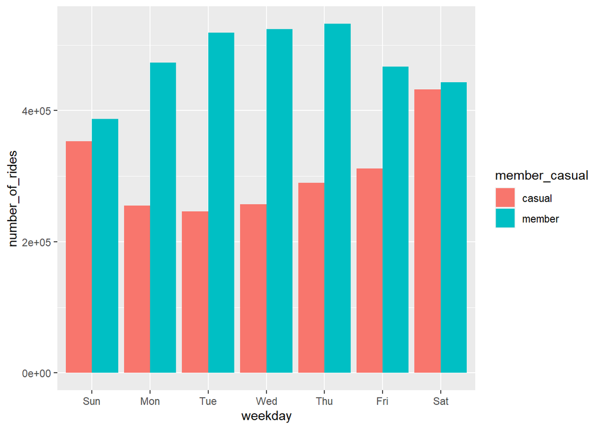

```r
ggplot(all_trips_4, mapping = aes(x=weekday, y=number_of_rides, fill= member_casual)) +
geom_col(position = "dodge")
```

This bar graph shows member vs casual ridership count for each day of the week.

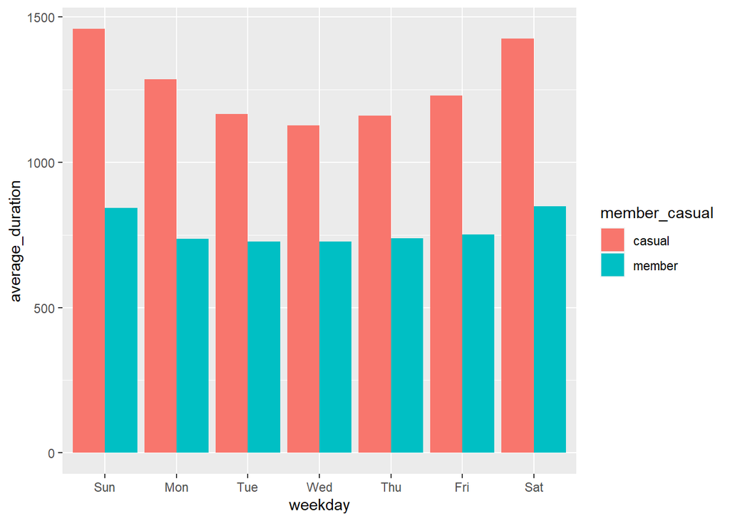

```r
ggplot(all_trips_4, mapping = aes(x=weekday, y=average_duration, fill= member_casual)) +
geom_col(position = "dodge")
```

This bar graph shows the average_duration of rides based on membership type for each day of the week.

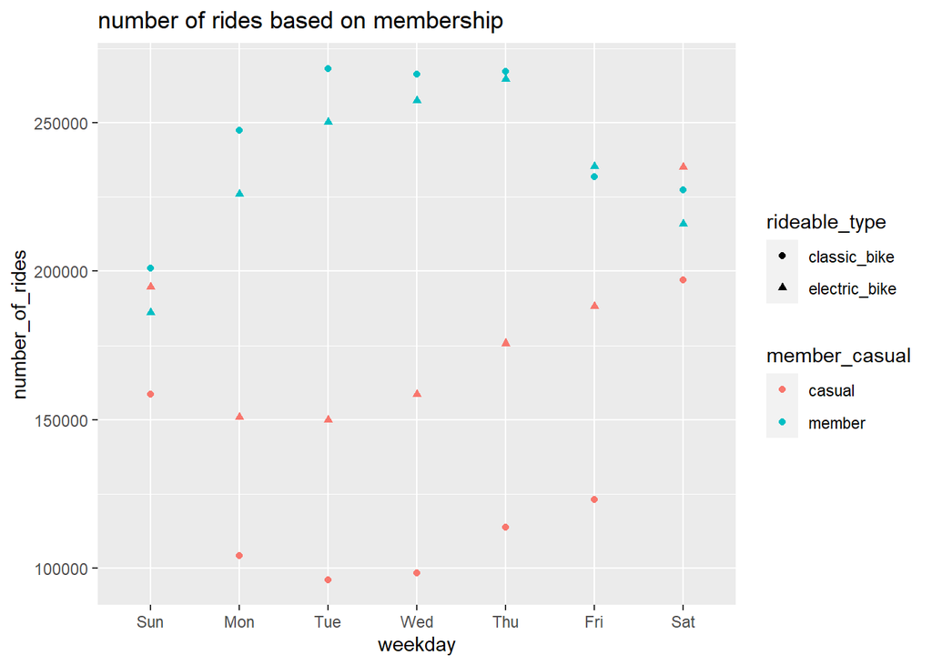

```r
ggplot(all_trips_5) +
geom_point(mapping = aes(x=weekday, y=number_of_rides, color= member_casual, shape = rideable_type)) +
labs(title = "number of rides based on membership")
```

This visualization catagorizes number_of_rides based on rideeable_type and membership type for each day of the week.

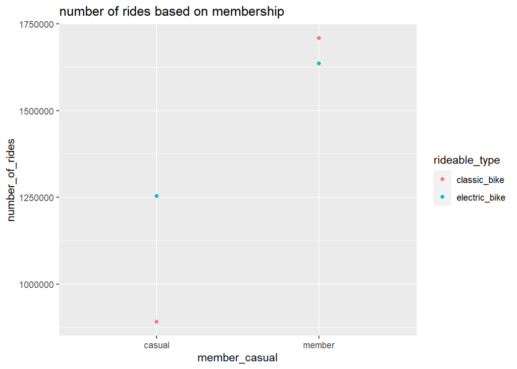

```r
ggplot(all_trips_6) +
geom_point(mapping = aes(x=member_casual, y=number_of_rides, color=rideable_type)) +
labs(title = "number of rides based on membership")
```